# Working with Bchron Package

Trial for running Bchron I’ve already calibrated my radiocarbon dates with Calib, but I wanted to mess around with the Bchron package mostly to use the BchronDensity function to visualize my dates. I’m using this site: https://cran.r-project.org/web/packages/Bchron/vignettes/Bchron.html for reference.

```r
library(cowplot)
```

Calibrating radiocabon dates

```r
red_c14 <- read.csv(file = "red14_bchron.csv")
# testing for first date
age1 = BchronCalibrate(ages = 480,
                        ageSds = 30, #standard deviation of age
                        calCurves = "intcal13", #calibration curve (choice of intcal13, shcal13 and marine13)
                        ids = "WOMT-01d5") #id number of date
summary(age1)
```

```
95% Highest density regions for WOMT-01d5
$`91.3%`
[1] 501 539
```

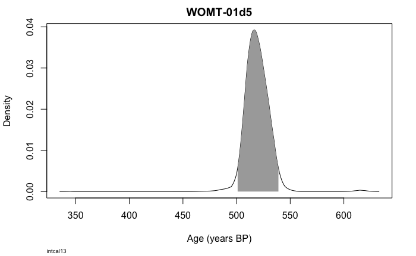

```r
plot(age1, xlab = "Age (years BP)")
```

So far, the one downside is that I’ll need to enter each of my dates in a vector. Since I have 45, I’m going to try a work around.

Alright, now let’s mess with the BchronDensity function:

[figure not shown]

```r
# removed the sites from the red_c14 file in excel for time's sake
red_c14_normal <- read.csv(file = "red14_bchron_normal.csv")
# calibrating
red_ages_norm <- red_c14_normal$ages
red_SDs_norm <- red_c14_normal$SD
red_depth_norm <- red_c14_normal$depth
red_cal_norm <- rep("intcal13", times = length(red_ages_norm))
all_ages_norm = BchronCalibrate(ages = red_ages_norm,
                           ageSds = red_SDs_norm,
                           positions = red_depth_norm,
                           calCurves = red_cal_norm)
summary(all_ages_norm)
```

```
95% Highest density regions for Date1
$`91.3%`
[1] 501 539


95% Highest density regions for Date2
$`19.1%`
[1] 558 604

$`74%`
[1] 627 684


95% Highest density regions for Date3
$`16.8%`
[1] 532 566

$`76.8%`
[1] 586 645


95% Highest density regions for Date4
$`34.1%`
[1] 317 398

$`60.2%`
[1] 422 499


95% Highest density regions for Date5
$`34.1%`
[1] 317 398

$`60.2%`
[1] 422 499


95% Highest density regions for Date6
$`5.1%`
[1]  0 36
```

[output cut: 191 more lines]

```
[1] 4141 4259

$`21.1%`
[1] 4263 4286


95% Highest density regions for Date28
$`6.3%`
[1]  0 23

$`48.5%`
[1] 142 219

$`39.1%`
[1] 265 301
```

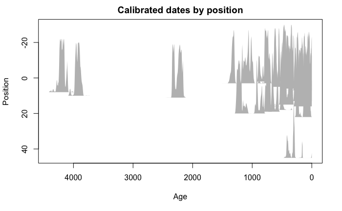

```r
plot(all_ages_norm, withPositions=TRUE)
```

```r
# bchron density
# red_density_norm = BchronDensity(ages = red_ages_norm, ageSds = red_SDs_norm, calCurves = red_cal_norm)
# plot(red_density_norm, bty = "n", xlab = "Age (cal years BP)")
rm(red_density_norm)
```

```
object 'red_density_norm' not found
```

but, what if I could do this in ggplot…

```r
# install.packages("devtools")
library(devtools)
devtools::install_github('andrewcparnell/Bchron')
library(Bchron)
data(red_c14_normal)
```

```
data set ‘red_c14_normal’ not found
```

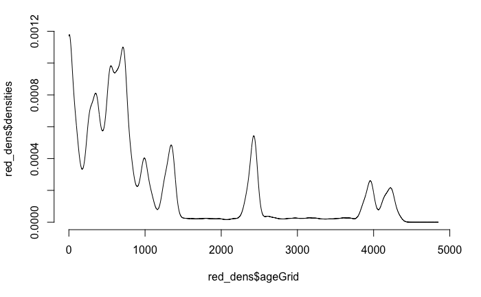

```r
red_dens <- BchronDensity(ages=  red_c14_normal$ages, ageSds = red_c14_normal$SD, calCurves = red_cal_norm, numMix = 50, store_density = TRUE)
plot(red_dens$ageGrid, red_dens$densities, type = 'l', bty = "n")
```

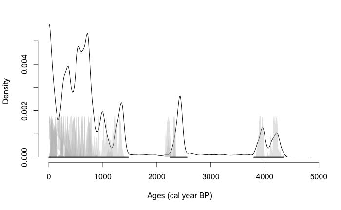

```r
plot(red_dens, bty = "n",
     xlab = "Ages (cal year BP)")
```

I should probably also do this for the colluvial hollow/etc

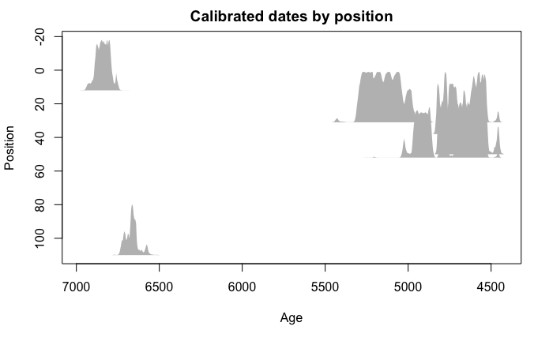

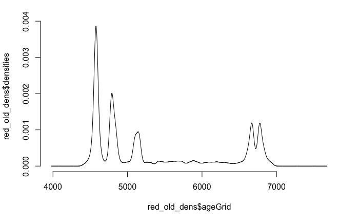

```r
# using just the non soil sites
old_red_input <- red_c14[which(red_c14$ages >= 4000),]
old_red_cal_curve <- rep("intcal13", times = length(old_red_input$ages))
old_red_c14 <- BchronCalibrate(ages = old_red_input$ages, # calibrating
                                   ageSds = old_red_input$SD,
                                   positions = old_red_input$depth,
                                   calCurves = old_red_cal_curve)
# plotting by position
plot(old_red_c14, withPositions = TRUE)
# plotting by density
red_old_dens <- BchronDensity(ages= old_red_input$ages,
                          ageSds = old_red_input$SD,
                          calCurves = old_red_cal_curve, numMix = 50,
                          store_density = TRUE)
plot(red_old_dens$ageGrid, red_old_dens$densities, type = 'l', bty = "n")
```

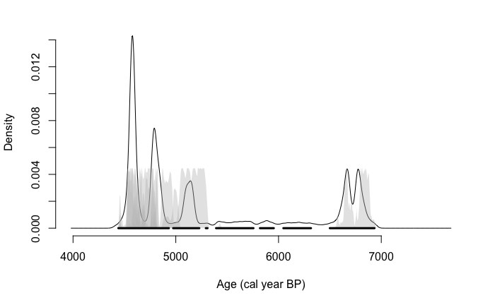

```r
plot(red_old_dens, bty = "n",
     xlab = "Age (cal year BP)")
```

Alright, let’s get that out of Bchrondensity format:

[figure not shown]

| age_grid | densities | type |
| --- | --- | --- |
| 0 | 1.434101e-03 | 1 |
| 1 | 1.434833e-03 | 1 |
| 2 | 1.434906e-03 | 1 |
| 3 | 1.434321e-03 | 1 |
| 4 | 1.433081e-03 | 1 |
| 5 | 1.431191e-03 | 1 |
| 6 | 1.428656e-03 | 1 |
| 7 | 1.425481e-03 | 1 |
| 8 | 1.421673e-03 | 1 |
| 9 | 1.417240e-03 | 1 |

[output cut: 990 more lines]

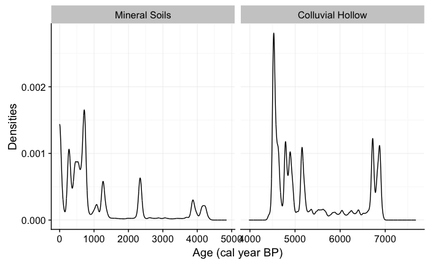

```r
# i might try the facet_grid function:
# need to change out of BchronDensity format, and want to clean up my names a bit
    # younger dates first
    red_dens_ggplot <- data.frame(red_dens$ageGrid, red_dens$densities)
    red_dens_ggplot$type <- rep(1, length.out = length(red_dens_ggplot$red_dens.ageGrid))
    names(red_dens_ggplot) <- c("age_grid", "densities", "type")
    red_dens_ggplot

    # same thing for older
    old_dens_ggplot <- data.frame(red_old_dens$ageGrid, red_old_dens$densities)
    old_dens_ggplot$type <- rep(2,
                                length.out =length(old_dens_ggplot$red_old_dens.ageGrid))
    names(old_dens_ggplot) <- c("age_grid", "densities", "type")
# so, let's put them together
complete_density <- rbind(red_dens_ggplot, old_dens_ggplot)
# now, to plot:
complete_density$type2 <- factor(complete_density$type, labels = c("Mineral Soils", "Colluvial Hollow")) # the solution for my facet label problem, no idea why
ggplot(complete_density, aes(x = complete_density$age_grid, y = complete_density$densities)) + geom_line() + facet_grid(. ~ complete_density$type2, scales = "free_x") + background_grid(major = "xy") + labs(x = "Age (cal year BP)", y = "Densities")
```

Pretty happy with that, minus the weird overlap. I think I may just clip the agegrid for the younger dates, I think that may solve the issue.

```r
# clipping overlap
red_dens_ggplot <- red_dens_ggplot[-which(red_dens_ggplot$age_grid > 4500),]
old_dens_ggplot <- old_dens_ggplot[-which(old_dens_ggplot$age_grid < 4250),]

complete_density <- rbind(red_dens_ggplot, old_dens_ggplot)
complete_density$type2 <- factor(complete_density$type, labels = c("Mineral Soils", "Colluvial Hollow/Alluvial Fan"))

# giving dates a y-axis
dates <- read.csv("dates.csv")
dates <- dates[-which(is.na(dates$error)),]
length(dates$median_cal_age)
dates$y_axis <- rep(0.003, each = 40)

density_facet_plot <- ggplot(complete_density,
                             aes(x = complete_density$age_grid, y = complete_density$densities)) +  geom_line() +
  facet_grid(. ~ complete_density$type2, scales = "free_x") +
  background_grid(major = "xy") +
  labs(x = "Age (cal year BP)", y = "Densities",
       title = "Estimate of Site Activity",
       subtitle = "Results of Bchron Gaussian Mixture Model") +
  panel_border() +
  theme(plot.title = element_text(hjust = 0))

density_facet_plot + geom_point(data = dates, aes(x = dates$median_cal_age, y = dates$y_axis, color = "red", shape = 4))
ggplot(dates, aes(x = dates$median_cal_age, y = dates$y_axis)) + geom_point()

density_facet_plot

save_plot("density_facet_plot.png", density_facet_plot, ncol = 2, base_aspect_ratio = 1.1 )
```

[output not shown]

Yeah!!

# Related radiocarbon figures

Now that I’ve tackled the Bchron figures, I should also probably back up and tackle some of the more straightforward radiocarbon graphs (date vs depth, age reversals, etc). I’ll start by checking on what sorts of data files I have for that stuff, and how I’ll need to clean it up to make it work.

```r
# ggplot(dates, aes(x = dates$median_cal_age, y = dates$depth, color = factor(dates$site_type))) + geom_point() + facet_grid(dates$site_type ~ dates$site, scales = "fixed")  + background_grid(major="xy") + scale_y_reverse()  + panel_border()
```

Well, that’s a nightmare. I think the best way to clean that up is to split data between mineral soil and the other two (as I did with the bchron data)

```r
# parsing out mineral soil data
valley_ms <- dates[which(dates$site_type == "valley mineral soil"),]
hillslope_ms <- dates[which(dates$site_type == "hillslope mineral soil"),]
ridgetop_ms <- dates[which(dates$site_type == "ridgetop mineral soil"),]
ms_dates <- merge(valley_ms, ridgetop_ms, all = TRUE)
ms_dates <- merge(ms_dates, hillslope_ms, all = TRUE)

ms_ggplot <- ggplot(ms_dates, aes(x = ms_dates$median_cal_age, y = ms_dates$depth, color = ms_dates$site_type, fill = ms_dates$site_type, shape = ms_dates$site_type)) +
  geom_point(size = 4) +
  scale_shape_manual(values = c(21, 22, 24),
                     name = "Site Type:",
                     labels = c("Hillslope Mineral Soil", "Ridgetop Mineral Soil", "Valley Mineral Soil")) +
  scale_color_manual(values = c("#202020", "#E69F00", "#56B4E9"),
                     name = "Site Type:",
                     labels = c("Hillslope Mineral Soil", "Ridgetop Mineral Soil", "Valley Mineral Soil")) +
  scale_fill_manual(values = c("#20202080", "#E69F0080", "#56B4E980"),
                    labels = c("Hillslope Mineral Soil", "Ridgetop Mineral Soil", "Valley Mineral Soil"),
                    name = "Site Type:") +
  background_grid() + panel_border() + scale_y_reverse() + labs(x = "Age (cal year BP)", y = "Depth (cm)", title = "Forest Mineral Soil Sites")+
  theme(legend.position = "right")
ms_ggplot
save_plot("ms_ggplot.png", ms_ggplot, base_height = 4, base_width = NULL, base_aspect_ratio = 1.5)
```

[output not shown]

That’s a start. Let’s do the same with the other data types:

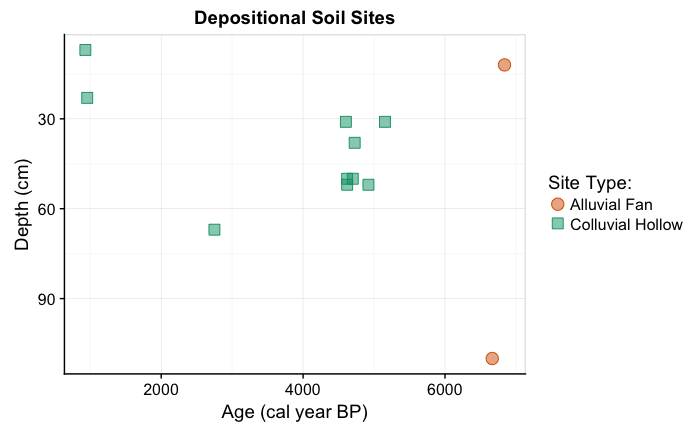

Saving just a copy of the two points

```r
date_point_ggplot <- plot_grid(ms_ggplot, ns_ggplot, labels = c("A.", "B."), nrow = 1, align = "h", rel_heights = c(1,1), rel_widths = c(12,12))
date_point_ggplot
save_plot("date_point.png", date_point_ggplot,ncol = 1, nrow = 2, base_aspect_ratio = 1.8, base_height = 4)
```

[output not shown]

```r
dates_ggplot <- plot_grid(ms_ggplot, ns_ggplot, density_facet_plot, NULL, labels = c("A.", "B.", "C."))
dates_ggplot

# trying to fix alignment issue
# aligning top row (density plot) with bottom left (mineral soil)
plots <- align_plots(ms_ggplot, density_facet_plot, align = "v", axis = "l")
plots
# build bottom row
bottom_row <- plot_grid(plots[[1]], ns_ggplot, labels = c("B.", "C."), align = "h",axis = "b", rel_widths = c(1.5, 1.5))
plot_grid(plots[[2]], bottom_row, labels = c("A.", ""), ncol = 1, rel_heights = c(1.2, 1.2), rel_widths = c(0.5,1))
# nah I don't like how that looks

bottom_row <- plot_grid(ms_ggplot, ns_ggplot, labels = c("B.", "C."), align = "h", rel_widths = c(1.5,1.5))
date_facet_plot <- plot_grid(density_facet_plot, bottom_row, labels = c("A.", ""), ncol = 1, rel_heights = c(1.25, 1.5), rel_widths = c(0.95, 1))
date_facet_plot
# that's what I want but the y axis for the top and bottom aren't aligned...
# OH WELL FOR NOW
save_plot("date_facet_plot.png", date_facet_plot, nrow = 2, ncol = 2, base_aspect_ratio = 1.1)
```

[output not shown]

Mmmm I think I’ll try it with densities on the bottom, maybe the axes will align better in that position:

```r
# Switching order / fixing alignment issue
# aligning top row (soils) with bottom left (densities)
plots <- align_plots(ms_ggplot, density_facet_plot, align = "v", axis = "l")
# build bottom row
bottom_row <- plot_grid(plots[[1]], ns_ggplot, labels = c("B.", "C."), align = "h", axis = "b", rel_widths = c(1.5, 1.5))
plot_grid(plots[[2]], bottom_row, labels = c("A.", ""), ncol = 1, rel_heights = c(1.2, 1.2))
# nah I don't like how that looks
```

[output not shown]

# Age Reversal

I also need to re-create the age-reversal graph I drew up in excel. I’m guessing the geom_point function should help with the plotting issues I’ve had, but I need to figure out how to cross-index the data appropriately. I think if I start with each site_type category file, I can do them relatively quickly by hand and then add back together with an age_reversal / depth_reversal column for each. #### 5/6/18 - Just kidding, did it all in excel

```r
age_reverse <- read.csv('age_reverse.csv')

site_labels <- c("Alluvial Fan", "Colluvial Hollow","Hillslope Mineral Soil", "Ridgetop Mineral Soil", "Valley Mineral Soil")
site_colors <- c("#D55E00", "#009E73", "#202020", "#E69F00", "#56B4E9")
site_fill <- c("#D55E0080", "#009E7380", "#20202080", "#E69F0080", "#56B4E980")

age_reverse_ggplot <- ggplot(age_reverse, aes(x = age_reverse$depth_reversal, y = age_reverse$age_reversal, color = age_reverse$site_type, shape = age_reverse$site_type, fill = age_reverse$site_type)) +
  geom_point(size = 4) +
  scale_shape_manual(values = c(21,22,21, 22, 24),
                     name = "Site Type:",
                     labels = site_labels) +
  scale_color_manual(values = site_colors,
                     name = "Site Type:",
                     labels = site_labels) +
  scale_fill_manual(values = site_fill, name = "Site Type:",
                    labels = site_labels) +
  geom_hline(yintercept = 0) +
  background_grid( major = "xy") + panel_border() +
  xlab("Difference in depth in soil (cm)") + ylab("Difference in age (cal yr BP)") +
  labs(title = "Age Reversal of Radiocarbon Dates") +
  annotate("text", x = c(88,85), y = c(-3800,4225), label = c("Age Reversal", "No Age Reversal"))
age_reverse_ggplot
save_plot("age_reverse.png", age_reverse_ggplot, base_aspect_ratio = 1.8, base_height = 4)
```

[output not shown]

```r
length(which(age_reverse$age_reversal < 0)) # age reversal
length(which(age_reverse$age_reversal > 0)) # no age reversal
```

[output not shown]

# Linear Regression

Running a linear regression on age vs depth.

```r
# running linear regression on MS dates
linearmod <- lm(formula = ms_dates$depth ~ ms_dates$median_cal_age, data = ms_dates)
print(linearmod)
summary(linearmod)
```

[output not shown]

```r
plot(ms_dates$median_cal_age ~ ms_dates$depth, data = ms_dates)
abline(linearmod)
```

[output not shown]

# comparing against norman

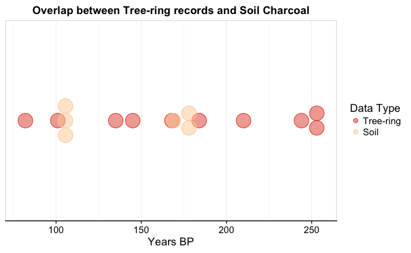